# November Year Module Summary

2022-07-06

### 0.0.1 Background

Exploration of discard estimates from november year module

### 0.0.2 Steps

1. pull all merged trips from CAMS_OBS_CATCH
2. Set stratification variables for all trips

```r
# FULL Stratification variables

stratvars = c('SPECIES_ESTIMATION_REGION'
              ,'CAMS_GEAR_GROUP'
                            , 'MESHGROUP'
                          , 'TRIPCATEGORY'
                          , 'ACCESSAREA')
```

```
- SPECIES_ESTIMATION_REGION is taken from CAMS support table `MAPS.CAMS_STATAREA_STOCK`
- CAMS_GEAR_GROUP is derived from a support table (`MAPS.CAMS_GEARCODE_STRATA`)
- MESHGROUP is hardcoded for all trips according to decisions made by the mesh subgroup (see summary when available)
- SECTID comes from a CAMS matching table (`MAPS.MATCH_MULT_SECTID`)
```

3. Run `discaRd`
   - there are sub-passes for year t and year t-1

```r
# Assumed Stratification variables

stratvars = c('SPECIES_ESTIMATION_REGION'
              , 'CAMS_GEAR_GROUP',
              ,'MESHGROUP')
```

4. The discaRd functions allow for an assumed rate to be calculated. This assumed rate is relative to the stratification used in the functions. Here, the stratification is coarsened to ‘SPECIES_ESTIMATION_REGION’, ‘CAMS_GEAR_GROUP’and ’MESHGROUP’.
5. A transition rate is calculated between year t and year t-1. This rate determines how much, if any, information is used from previous years.
6. A broad stock/gear stratification is applied to subtrips that do not meet the requirements for the full or assumed stratification. This broad stock/gear stratification utilizes observed coverage from both the focal year and the previous year as it includes gear types with low observer coverage.
7. Rates and `DISCARD_SOURCE` (in parentheses) are assigned for each trip according to:
- 1. in season rate; >= 5 trips in Full Stratification
- 20. Transition in season rate; < 5 trips in Full Stratification, year t, AND >= 5 trips in year t-1
- 1. Assumed rate. This is the rate when there were <5 trips in season and <5 in previous season.
- 7. Broad stock/gear rate <5 trips in season and <5 trips in previous season
- 14. No coverage in focal season and previous season; discard rate is not possible to estimate.
- 15. Observed values used from observed rate trips; discard rate is NOT USED.
9. CV calculations are available for (I), (T), (A) and (G).
10. Discard pounds per trip are calculated according to

```r
    mutate(DISC_MORT_RATIO = coalesce(DISC_MORT_RATIO, 1)) %>%
    mutate(DISCARD = case_when(!is.na(LINK1) ~ DISC_MORT_RATIO*OBS_DISCARD
                                                         , is.na(LINK1) ~ DISC_MORT_RATIO*COAL_RATE*LIVE_POUNDS)

            # COAL_RATE is the final discard rate used. It is 'coalesced' from the (I), (A) and (G) rates
```

By assigning `SPECIES_ESTIMATION_REGION` as a stratification variable, the computation time is reduced. Each subtrip may only occur in a single statistical area so it should never cross stock boundaries.

Output tables are produced for each species. These can easily be recombined. Preliminary species tables have been shared on `MAPS` and `CAMS_GARFO`.

```sql
    MAPS.CAMS_DISCARD_GOLDENTILEFISH_19
    CAMS_GARFO.CAMS_DISCARD_GOLDENTILEFISH_19

    MAPS.CAMS_DISCARD_BLUELINETILEFISH_19
    CAMS_GARFO.CAMS_DISCARD_BLUELINETILEFISH_19
```

### 0.0.3 Diagnostic Plots/Tables

[output not shown]

2019 Federal Discard Totals by Source

[output not shown]

2019 CAMS State Discard Totals

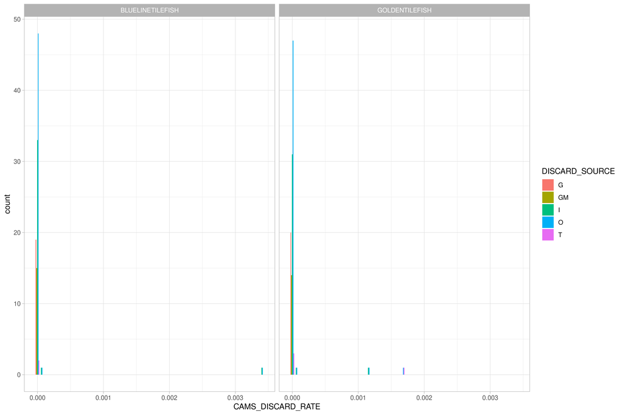

Histogram of Discard Rates by Species, Strata and Discard Source for Federal trips

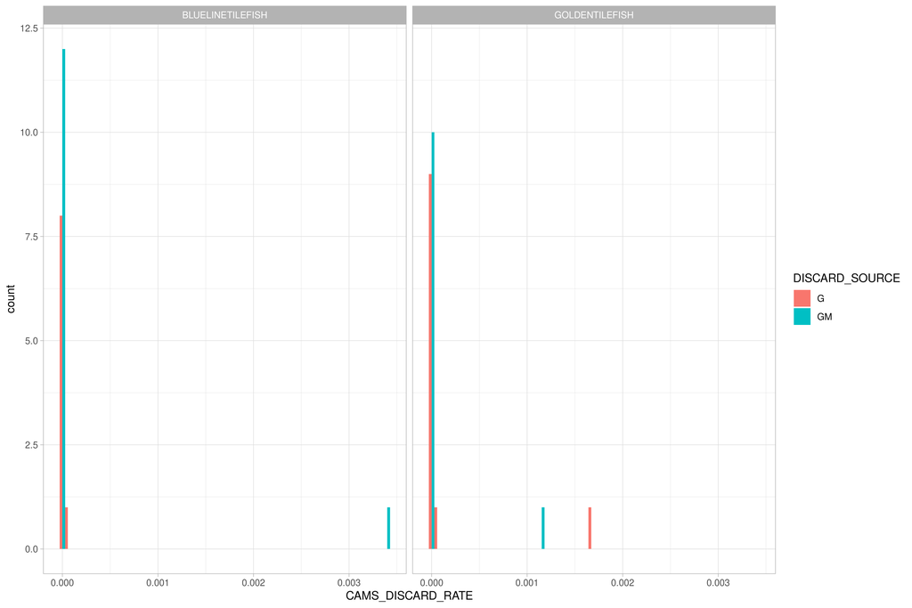

Histogram of Discard Rates by Species, Strata and Discard Source for State trips

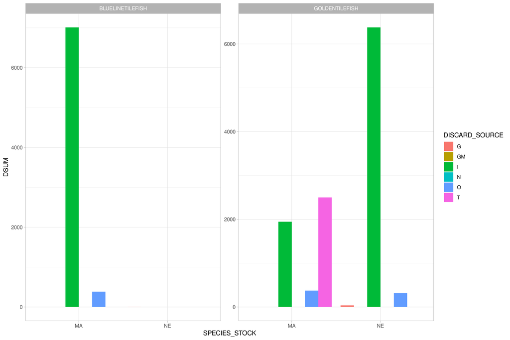

Total Discard Estimates by Species, Stock and Discard Source for Federal trips

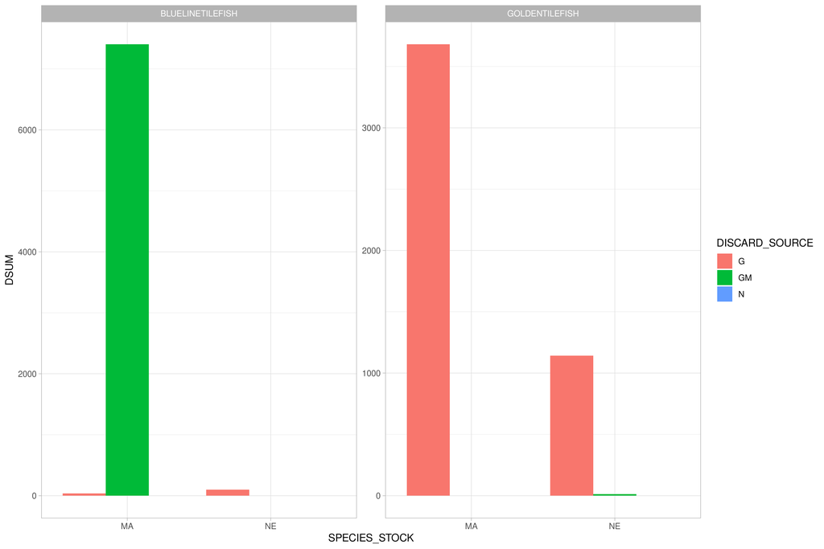

Total Discard Estimates by Species, Stock and Discard Source for State trips

|  | STRATA_FULL | DISCARD_SOURCE | CAMS_DISCARD_RATE | SUBTRIP_KALL | DISC_MORT_RATIO | DISCARD |
| --- | --- | --- | --- | --- | --- | --- |
| 1 | NE_10_na_all_all | I | 0.00114 | 5165582 | 1 | 5911 |
| 2 | MA_10_na_all_all | T | 0.00167 | 1495944 | 1 | 2501 |
| 3 | MA_50_SM_all_all | I | 4e-05 | 42397564 | 1 | 1897 |
| 4 | NE_50_SM_all_all | I | 1e-05 | 46016528 | 1 | 388 |
| 5 | NE_50_LM_all_all | I | 0 | 55237410 | 1 | 80 |
| 6 | MA_50_LM_all_all | I | 0 | 16120295 | 1 | 48 |
| 7 | NE_100_na_all_all | G | 2e-05 | 1726569 | 1 | 36 |
| 8 | NE_100_SM_all_all | G | 2e-05 | 88750 | 1 | 2 |
| 9 | MA_50_LM_GEN_AA | GM | 0 | 170312 | 1 | 1 |
| 10 | MA_50_LM_GEN_OPEN | GM | 0 | 179085 | 1 | 1 |

[output cut: 74 more lines]

|  | STRATA_FULL | DISCARD_SOURCE | CAMS_DISCARD_RATE | SUBTRIP_KALL | DISC_MORT_RATIO | DISCARD |
| --- | --- | --- | --- | --- | --- | --- |
| 1 | MA_10_na_NA_NA | G | 0.00167 | 2165993 | 1 | 3621 |
| 2 | NE_100_na_NA_NA | G | 2e-05 | 54795343 | 1 | 1140 |
| 3 | MA_50_na_NA_NA | G | 5e-05 | 1248708 | 1 | 61 |
| 4 | NE_10_na_NA_NA | GM | 0.00114 | 11464 | 1 | 13 |
| 5 | NE_50_na_NA_NA | G | 0 | 801767 | 1 | 3 |
| 6 | MA_100_na_NA_NA | G | 0 | 96429505 | 1 | 0 |
| 7 | MA_132_na_NA_NA | GM | 0 | 548847 | 1 | 0 |
| 8 | MA_180_na_NA_NA | GM | 0 | 60153028 | 1 | 0 |
| 9 | MA_181_na_NA_NA | G | 0 | 2029805 | 1 | 0 |
| 10 | MA_183_na_NA_NA | GM | 0 | 3536807 | 1 | 0 |

[output cut: 19 more lines]

|  | STRATA_FULL | DISCARD_SOURCE | CAMS_DISCARD_RATE | SUBTRIP_KALL | DISC_MORT_RATIO | DISCARD |
| --- | --- | --- | --- | --- | --- | --- |
| 1 | MA_10_na_all_all | I | 0.0034 | 1590465 | 1 | 5408 |
| 2 | MA_50_SM_all_all | I | 4e-05 | 42684664 | 1 | 1602 |
| 3 | NE_100_na_all_all | G | 0 | 1726569 | 1 | 3 |
| 4 | MA_100_LM_all_all | I | 0 | 10132275 | 1 | 0 |
| 5 | MA_100_na_all_all | G | 0 | 1439252 | 1 | 0 |
| 6 | MA_100_SM_all_all | I | 0 | 1683741 | 1 | 0 |
| 7 | MA_100_XL_all_all | I | 0 | 5403648 | 1 | 0 |
| 8 | MA_132_na_all_all | GM | 0 | 365512 | 1 | 0 |
| 9 | MA_132_na_GEN_AA | I | 0 | 6302919 | 1 | 0 |
| 10 | MA_132_na_GEN_OPEN | I | 0 | 5375845 | 1 | 0 |

[output cut: 75 more lines]

|  | STRATA_FULL | DISCARD_SOURCE | CAMS_DISCARD_RATE | SUBTRIP_KALL | DISC_MORT_RATIO | DISCARD |
| --- | --- | --- | --- | --- | --- | --- |
| 1 | MA_10_na_NA_NA | GM | 0.0034 | 2177741 | 1 | 7405 |
| 2 | NE_100_na_NA_NA | G | 0 | 54795343 | 1 | 99 |
| 3 | MA_50_na_NA_NA | G | 3e-05 | 1280035 | 1 | 37 |
| 4 | MA_100_na_NA_NA | G | 0 | 105718152 | 1 | 0 |
| 5 | MA_132_na_NA_NA | GM | 0 | 548847 | 1 | 0 |
| 6 | MA_180_na_NA_NA | GM | 0 | 66103323 | 1 | 0 |
| 7 | MA_181_na_NA_NA | G | 0 | 2051557 | 1 | 0 |
| 8 | MA_183_na_NA_NA | GM | 0 | 3680869 | 1 | 0 |
| 9 | MA_20_na_NA_NA | GM | 0 | 2495939 | 1 | 0 |
| 10 | MA_200_na_NA_NA | GM | 0 | 135813 | 1 | 0 |

[output cut: 21 more lines]

|  | DISCARD_SOURCE | CAMS_GEAR_GROUP | SPECIES_STOCK | D | K | Drate | Dmort |
| --- | --- | --- | --- | --- | --- | --- | --- |
| 1 | I | 10 | NE | 5911 | 5165582 | 0.0011 | 1 |
| 2 | T | 10 | MA | 2501 | 1495944 | 0.0017 | 1 |
| 3 | I | 50 | MA | 1945 | 58517859 | 0 | 1 |
| 4 | I | 50 | NE | 467 | 101253938 | 0 | 1 |
| 5 | O | 10 | NE | 277 | 261229 | 0.0011 | 1 |
| 6 | O | 50 | MA | 268 | 7786832 | 0 | 1 |
| 7 | O | 10 | MA | 106 | 63673 | 0.0017 | 1 |
| 8 | O | 50 | NE | 39 | 16924160 | 0 | 1 |
| 9 | G | 100 | NE | 38 | 1815319 | 0 | 1 |
| 10 | GM | 50 | MA | 1 | 349397 | 0 | 1 |

[output cut: 78 more lines]

|  | DISCARD_SOURCE | CAMS_GEAR_GROUP | SPECIES_ESTIMATION_REGION | D | K | Drate | Dmort |
| --- | --- | --- | --- | --- | --- | --- | --- |
| 1 | G | 10 | MA | 3621 | 2165993 | 0.0017 | 1 |
| 2 | G | 100 | NE | 1140 | 54795343 | 0 | 1 |
| 3 | G | 50 | MA | 61 | 1248708 | 0 | 1 |
| 4 | GM | 10 | NE | 13 | 11464 | 0.0011 | 1 |
| 5 | G | 50 | NE | 3 | 801767 | 0 | 1 |
| 6 | G | 100 | MA | 0 | 96429505 | 0 | 1 |
| 7 | G | 121 | NE | 0 | 2962462 | 0 | 1 |
| 8 | G | 180 | NE | 0 | 6227705 | 0 | 1 |
| 9 | G | 181 | MA | 0 | 2029805 | 0 | 1 |
| 10 | G | 20 | MA | 0 | 2228420 | 0 | 1 |

[output cut: 19 more lines]

|  | DISCARD_SOURCE | CAMS_GEAR_GROUP | SPECIES_STOCK | D | K | Drate | Dmort |
| --- | --- | --- | --- | --- | --- | --- | --- |
| 1 | I | 10 | MA | 5408 | 1590465 | 0.0034 | 1 |
| 2 | I | 50 | MA | 1602 | 58930770 | 0 | 1 |
| 3 | O | 10 | MA | 196 | 63694 | 0.0034 | 1 |
| 4 | O | 50 | MA | 188 | 7858550 | 0 | 1 |
| 5 | G | 100 | NE | 3 | 1815319 | 0 | 1 |
| 6 | G | 100 | MA | 0 | 1439252 | 0 | 1 |
| 7 | G | 170 | MA | 0 | 11217697 | 0 | 1 |
| 8 | G | 180 | NE | 0 | 16184350 | 0 | 1 |
| 9 | G | 53 | NE | 0 | 79586 | 0 | 1 |
| 10 | G | 54 | MA | 0 | 393360 | 0 | 1 |

[output cut: 78 more lines]

|  | DISCARD_SOURCE | CAMS_GEAR_GROUP | SPECIES_ESTIMATION_REGION | D | K | Drate | Dmort |
| --- | --- | --- | --- | --- | --- | --- | --- |
| 1 | GM | 10 | MA | 7405 | 2177741 | 0.0034 | 1 |
| 2 | G | 100 | NE | 99 | 54795343 | 0 | 1 |
| 3 | G | 50 | MA | 37 | 1280035 | 0 | 1 |
| 4 | G | 100 | MA | 0 | 105718152 | 0 | 1 |
| 5 | G | 121 | NE | 0 | 2962462 | 0 | 1 |
| 6 | G | 180 | NE | 0 | 6227705 | 0 | 1 |
| 7 | G | 181 | MA | 0 | 2051557 | 0 | 1 |
| 8 | G | 50 | NE | 0 | 801767 | 0 | 1 |
| 9 | G | 59 | MA | 0 | 308190 | 0 | 1 |
| 10 | G | 59 | NE | 0 | 103 | 0 | 1 |

[output cut: 21 more lines]

### 0.0.4 Appendix

For more information regarding stratification variables and discard rates by species see

MAPS.CAMS_STATAREA_STOCK MAPS.CAMS_DISCARD_MORTALITY_STOCK MAPS.CAMS_GEARCODE_STRATA MAPS.CAMS_MASTER_GEAR MAPS.CAMS_OBS_CATCH